# Analysing/Aggregating the data

# Aim

In this file we look at some of the aggregate data summaries with a view to identifying ways in which we can analyse/structure the data in order to extract richer meaning. We can think of two types of DD aggregation, which could be done sequentially:

1. The LIDD 7-fold taxonomy of DD instruments
2. A 3-fold typology of DD instruments presented below

# 1) The LIDD 7-fold taxonomy

The LIDD dataset is structured according to a “Country X Instrument” combination, which we can think of as “cases”. Indeed the Country X Instrument is the basic unit of analysis, whether we have a 7-fold or additional typologies.

There are 47 countries and 7 instruments. If every CoE country provided for the 7 instruments of DD we identify in LIDD, there would be 329 cases. However, the actual population of cases is rather more limited at 139 cases. This means that about 40 percent of the possible “country X instrument” combinations can be empirically observed, while 60 percent do not exist. The graph below illustrates this with 2 countries possesing nearly the full range of DD instruments while 4 coutries only possess a single instrument. The rest of the countries occuppy intermediate groupings.

The median number of DD instruments across the 47 CoE countries is 3 (the mean average is 2.96) -note this average also includes the 6 countries without DD instrument.

## Number of instruments

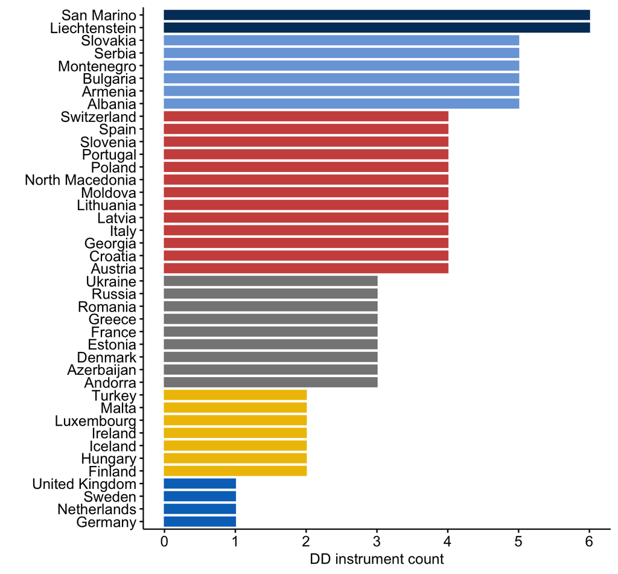

#### The following 6 countries do not provide for any DD instrument at national level according to the LIDD criteria

| Country |
| --- |
| Belgium |
| Bosnia and Hercegovina |
| Cyprus |
| Czech Republic |
| Monaco |
| Norway |

## The empirical distribution of the LIDD 7-fold taxonomy

The emprical distribution we observe for the Country x Instrument combination looks like the matrix below.

#### The following 41 countries provide for various types of DD instruments according to the LIDD criteria

| Country | N | Agenda initiative | Executive-initiated | Law-initiated | Legislature-initiated | Proactive initiative | Rejective initiative | Subnational-initiated |
| --- | --- | --- | --- | --- | --- | --- | --- | --- |
| Liechtenstein | 6 | 1 |  | 1 | 1 | 1 | 1 | 1 |
| San Marino | 6 | 1 |  | 1 | 1 | 1 | 1 | 1 |
| Albania | 5 | 1 | 1 |  | 1 | 1 | 1 |  |
| Armenia | 5 | 1 | 1 | 1 | 1 | 1 |  |  |
| Bulgaria | 5 | 1 | 1 |  | 1 | 1 |  | 1 |
| Montenegro | 5 | 1 | 1 | 1 | 1 | 1 |  |  |
| Serbia | 5 | 1 | 1 | 1 | 1 | 1 |  |  |
| Slovakia | 5 | 1 | 1 | 1 | 1 | 1 |  |  |
| Austria | 4 | 1 | 1 | 1 | 1 |  |  |  |
| Croatia | 4 |  | 1 | 1 | 1 | 1 |  |  |
| Georgia | 4 | 1 | 1 |  | 1 | 1 |  |  |
| Italy | 4 | 1 |  |  | 1 |  | 1 | 1 |
| Latvia | 4 | 1 |  | 1 | 1 | 1 |  |  |
| Lithuania | 4 | 1 |  | 1 | 1 | 1 |  |  |
| Moldova | 4 |  | 1 | 1 | 1 | 1 |  |  |
| North Macedonia | 4 | 1 |  | 1 | 1 | 1 |  |  |
| Poland | 4 | 1 | 1 |  | 1 | 1 |  |  |
| Portugal | 4 | 1 | 1 |  | 1 | 1 |  |  |
| Slovenia | 4 | 1 | 1 |  | 1 |  | 1 |  |
| Spain | 4 | 1 | 1 | 1 | 1 |  |  |  |
| Switzerland | 4 |  |  | 1 |  | 1 | 1 | 1 |
| Andorra | 3 | 1 | 1 | 1 |  |  |  |  |
| Azerbaijan | 3 | 1 |  | 1 |  | 1 |  |  |
| Denmark | 3 | 1 |  | 1 | 1 |  |  |  |
| Estonia | 3 | 1 |  | 1 | 1 |  |  |  |
| France | 3 |  | 1 | 1 | 1 |  |  |  |
| Greece | 3 | 1 | 1 |  | 1 |  |  |  |
| Romania | 3 | 1 | 1 | 1 |  |  |  |  |
| Russia | 3 | 1 |  | 1 |  | 1 |  |  |
| Ukraine | 3 | 1 |  | 1 |  | 1 |  |  |
| Finland | 2 | 1 |  |  | 1 |  |  |  |
| Hungary | 2 |  | 1 |  |  | 1 |  |  |
| Iceland | 2 |  |  | 1 | 1 |  |  |  |
| Ireland | 2 |  |  | 1 | 1 |  |  |  |
| Luxembourg | 2 |  |  |  | 1 |  | 1 |  |
| Malta | 2 |  |  | 1 |  |  | 1 |  |
| Turkey | 2 |  | 1 | 1 |  |  |  |  |
| Germany | 1 |  |  | 1 |  |  |  |  |
| Netherlands | 1 | 1 |  |  |  |  |  |  |
| Sweden | 1 |  |  |  | 1 |  |  |  |
| United Kingdom | 1 |  |  |  | 1 |  |  |  |

## Presenting the dataset (wide format)

Here’s how the empirical dataset can be represented for analysis. It has 139 cases, the rows for each Country X Instrument combination, and we can simply add more columns/variables rightwards to the dataset, i.e. we can make the spreadsheet wider.

| Row | Country | Instrument | FormalLimits | FormalProcedures | subst_Limits | subst_Procedure | Organisation | Core | Fundamentals | Protection |
| --- | --- | --- | --- | --- | --- | --- | --- | --- | --- | --- |
| 1 | Albania | Agenda initiative | 25.0 | 0.0 | 0.0 | 0.0 | 0.000 | 0 | 0 | 0 |
| 2 | Albania | Executive-initiated | 0.0 | 0.0 | 29.4 | 37.5 | 0.000 | 50 | 25 | 50 |
| 3 | Albania | Legislature-initiated | 0.0 | 0.0 | 29.4 | 37.5 | 0.000 | 50 | 25 | 50 |
| 4 | Albania | Proactive initiative | 25.0 | 42.9 | 29.4 | 37.5 | 0.000 | 50 | 25 | 50 |
| 5 | Albania | Rejective initiative | 0.0 | 42.9 | 29.4 | 37.5 | 0.000 | 50 | 25 | 50 |
| 6 | Andorra | Agenda initiative | 25.0 | 0.0 | 0.0 | 0.0 | 0.000 | 0 | 0 | 0 |
| 7 | Andorra | Executive-initiated | 0.0 | 0.0 | 0.0 | 25.0 | 0.000 | 0 | 0 | 0 |
| 8 | Andorra | Law-initiated | 0.0 |  | 0.0 |  | 0.000 | 0 | 0 | 0 |
| 9 | Armenia | Agenda initiative | 25.0 | 0.0 | 35.3 | 0.0 | 0.000 | 50 | 50 | 50 |
| 10 | Armenia | Executive-initiated | 25.0 | 0.0 | 41.2 | 37.5 | 0.000 | 75 | 50 | 50 |
| 11 | Armenia | Law-initiated | 0.0 |  | 0.0 |  | 0.000 | 0 | 0 | 0 |
| 12 | Armenia | Legislature-initiated | 25.0 | 0.0 | 41.2 | 37.5 | 0.000 | 75 | 50 | 50 |
| 13 | Armenia | Proactive initiative | 25.0 | 0.0 | 41.2 | 37.5 | 0.000 | 75 | 50 | 50 |
| 14 | Austria | Agenda initiative | 0.0 |  | 0.0 | 25.0 | 0.000 | 0 | 0 | 0 |
| 15 | Austria | Executive-initiated | 0.0 | 0.0 | 11.8 | 0.0 | 33.333 | 0 | 0 | 0 |
| 16 | Austria | Law-initiated | 0.0 |  | 0.0 |  | 0.000 | 0 | 0 | 0 |
| 17 | Austria | Legislature-initiated | 0.0 | 0.0 | 11.8 | 0.0 | 33.333 | 0 | 0 | 0 |
| 18 | Azerbaijan | Agenda initiative | 75.0 | 71.4 | 58.8 | 0.0 | 33.333 | 50 | 75 | 75 |
| 19 | Azerbaijan | Law-initiated | 0.0 |  | 35.3 |  | 16.667 | 25 | 50 | 50 |
| 20 | Azerbaijan | Proactive initiative | 25.0 | 0.0 | 35.3 | 37.5 | 16.667 | 25 | 50 | 50 |
| 21 | Bulgaria | Agenda initiative | 0.0 | 0.0 | 0.0 | 0.0 | 0.000 | 0 | 0 | 0 |
| 22 | Bulgaria | Executive-initiated | 25.0 | 0.0 | 35.3 | 50.0 | 33.333 | 50 | 50 | 0 |
| 23 | Bulgaria | Legislature-initiated | 25.0 | 0.0 | 35.3 | 50.0 | 33.333 | 50 | 50 | 0 |
| 24 | Bulgaria | Proactive initiative | 25.0 | 42.9 | 35.3 | 50.0 | 33.333 | 50 | 50 | 0 |
| 25 | Bulgaria | Subnational-initiated | 25.0 | 0.0 | 35.3 | 50.0 | 33.333 | 50 | 50 | 0 |
| 26 | Croatia | Executive-initiated | 0.0 | 0.0 | 0.0 | 0.0 | 0.000 | 0 | 0 | 0 |
| 27 | Croatia | Law-initiated | 0.0 |  | 0.0 |  | 0.000 | 0 | 0 | 0 |
| 28 | Croatia | Legislature-initiated | 0.0 | 0.0 | 0.0 | 0.0 | 0.000 | 0 | 0 | 0 |
| 29 | Croatia | Proactive initiative | 25.0 | 42.9 | 0.0 | 50.0 | 0.000 | 0 | 0 | 0 |
| 30 | Denmark | Agenda initiative | 50.0 | 14.3 | 105.9 | 12.5 | 100.000 | 100 | 100 | 100 |

[output cut: 109 more lines]

### Issues with adding more columns/variables

Among the main issues for adding more variables, is that the items don’t apply to all instruments. In one case, the Agenda initiative, a referendum is not the outcome.

As an example, the following are *interesting* questions that can be posed, but from the 15 questions only 5 apply to all the instruments.

| Question | Agenda initiative | Executive-initiated | Law-initiated | Legislature-initiated | Proactive initiative | Rejective initiative | Subnational-initiated |
| --- | --- | --- | --- | --- | --- | --- | --- |
| Is there a formal admissibility check? | 1 | 1 |  | 1 | 1 | 1 | 1 |
| Is there a substantive admissibility check? | 1 | 1 |  | 1 | 1 | 1 | 1 |
| Are there any formal limits on the wording of the referendum proposal? | 1 | 1 | 1 | 1 | 1 | 1 | 1 |
| Is there a clarity of the question requirement? | 1 | 1 | 1 | 1 | 1 | 1 | 1 |
| Is there a unity of form requirement? | 1 | 1 | 1 | 1 | 1 | 1 | 1 |
| Is there a unity of substance requirement? | 1 | 1 | 1 | 1 | 1 | 1 | 1 |
| Can only issues of special importance be the subject of referendums? | 1 | 1 |  | 1 | 1 | 1 | 1 |
| Can only certain enumerated issues be the subject of referendums? | 1 | 1 |  | 1 | 1 | 1 | 1 |
| Are there any prohibited issues? | 1 | 1 | 1 | 1 | 1 | 1 | 1 |
| Is it mandatory to call the referendum? |  | 1 |  | 1 | 1 | 1 | 1 |
| Is the referendum result binding? |  | 1 | 1 | 1 | 1 | 1 | 1 |
| Turnout quorum |  | 1 | 1 | 1 | 1 | 1 | 1 |
| Approval quorum |  | 1 | 1 | 1 | 1 | 1 | 1 |
| Does any constitutional amendment trigger a referendum? |  |  | 1 |  |  |  |  |
| Do certain constitutional amendments trigger a referendum? |  |  | 1 |  |  |  |  |

### Adding more variables to the dataset (making it wider still)

| Country | Inst | formal-Check | subst-Check | formal-Wording | clarity-Req | unity-FormReq | unity-SubstReq | Special-Subjects | Enumerated-Only | Prohibited-Issues | Madatory-Call | Binding | Turnout-Quorum | Approval-Quorum | Const-Amend | Certain-ConstAmend |
| --- | --- | --- | --- | --- | --- | --- | --- | --- | --- | --- | --- | --- | --- | --- | --- | --- |
| Albania | Agenda initiative | No | No | No |  |  |  | No | No | No |  |  |  |  |  |  |
| Albania | Executive-initiated | No | Yes | No |  |  |  | Yes | No | Yes | No | Yes | No | Qualified majority |  |  |
| Albania | Legislature-initiated | No | Yes | No |  |  |  | Yes | No | Yes | No | Yes | No | Qualified majority |  |  |
| Albania | Proactive initiative | Yes | Yes | Yes | Yes | No | No | Yes | No | Yes | No | Yes | No | Qualified majority |  |  |
| Albania | Rejective initiative | Yes | Yes | No |  |  |  | No | No | Yes | Yes | Yes | No | Qualified majority |  |  |
| Andorra | Agenda initiative | No | Yes | No |  |  |  | No | No | Yes |  |  |  |  |  |  |
| Andorra | Executive-initiated | No | Yes | No |  |  |  | No | No | Yes | Yes | No | No | Simple majority |  |  |
| Andorra | Law-initiated |  |  | No |  |  |  |  |  | No |  | Yes | No | Simple majority | Yes | No |
| Armenia | Agenda initiative | No | No | No |  |  |  | No | No | Yes |  |  |  |  |  |  |
| Armenia | Executive-initiated | No | Yes | Yes | Yes | No | No | No | No | Yes | Yes | Yes | Yes | Simple majority |  |  |
| Armenia | Law-initiated |  |  | No |  |  |  |  |  | No |  | Yes | Yes | Simple majority | No | Yes |
| Armenia | Legislature-initiated | No | Yes | Yes | Yes | No | No | No | No | Yes | Yes | Yes | Yes | Simple majority |  |  |
| Armenia | Proactive initiative | No | Yes | Yes | Yes | No | No | No | No | Yes | Yes | Yes | Yes | Simple majority |  |  |
| Austria | Agenda initiative | Yes | Yes | Yes | No | No | No | No | No | No |  |  |  |  |  |  |
| Austria | Executive-initiated | No | No | No |  |  |  | Yes | No | Yes | No | No | No | Simple majority |  |  |
| Austria | Law-initiated |  |  | No |  |  |  |  |  | No |  | Yes | No | Simple majority | No | Yes |
| Austria | Legislature-initiated | No | No | No |  |  |  | Yes | No | Yes | No | Other | No | Simple majority |  |  |
| Azerbaijan | Agenda initiative | Yes | No | Yes | Yes | No | Yes | No | No | Yes |  |  |  |  |  |  |
| Azerbaijan | Law-initiated |  |  | Yes | No | No | No |  |  | Yes |  | Yes | Yes | Simple majority | Yes | No |
| Azerbaijan | Proactive initiative |  | Yes | No |  |  |  | No | Yes | Yes |  | Yes | Yes | Simple majority |  |  |
| Bulgaria | Agenda initiative | No | No | No |  |  |  | Yes | No | No |  |  |  |  |  |  |
| Bulgaria | Executive-initiated | No | Yes | Yes | Yes | No | No | Yes | No | Yes | No | Other | Yes | Simple majority |  |  |
| Bulgaria | Legislature-initiated | No | Yes | Yes | Yes | No | No | Yes | No | Yes | No | Other | Yes | Simple majority |  |  |
| Bulgaria | Proactive initiative | Yes | Yes | Yes | Yes | No | No | Yes | No | Yes | Other | Other | Yes | Simple majority |  |  |
| Bulgaria | Subnational-initiated | No | Yes | Yes | Yes | No | No | Yes | No | Yes | No | Other | Yes | Simple majority |  |  |
| Croatia | Executive-initiated | No | No | No |  |  |  | Yes | Yes | No | No | Yes | Yes | Simple majority |  |  |
| Croatia | Law-initiated |  |  | No |  |  |  |  |  | No |  | Yes | No | Simple majority | No | No |
| Croatia | Legislature-initiated | No | No | No |  |  |  | No | No | No | No | Yes | Yes | Simple majority |  |  |
| Croatia | Proactive initiative | Yes | Yes | Yes | Yes | No | No | No | No | No | Yes | Yes | Yes | Simple majority |  |  |
| Denmark | Agenda initiative | Yes | Yes | Yes | Yes | No | Yes | No | No | Yes |  |  |  |  |  |  |

[output cut: 109 more lines]

# 2) A three-fold typology

To do a more meaningful analysis we will probably need to disaggregate the data by types of instruments. The two are not mutually exclusive, they just operate at different levels of aggregation.

We can say quite a lot about the 7-fold taxonomy across the CoE countries, but I think we need to dig deeper and look at instruments that are more similar in type to avoid unnecessary replication of cases.

It seems to me we have 3 basic referendum typologies:

0. The Agenda initiative (ignored below)
1. Bottom-up instruments (Rejective + Proactive)
2. Top-down (Legislature/Executive, (subational, ignored below))
3. Law-initiated

From looking at the data above it seems that, in most cases, the values between some of the similar instruments are simply repeated for the countries. To i) avoid, replicating cases that are essentially the same and ii) to evaluate a more similar range of items per instrument we could look at subsets 1:3 above. The examples are listed below, and it would be a case of simply adding more variables (make the dataset wider).

# The Bottom-up dataset structure (Country N=25)

| row | Country | N_instrument |
| --- | --- | --- |
| 1 | Albania | 2 |
| 2 | Armenia | 1 |
| 3 | Azerbaijan | 1 |
| 4 | Bulgaria | 1 |
| 5 | Croatia | 1 |
| 6 | Georgia | 1 |
| 7 | Hungary | 1 |
| 8 | Italy | 1 |
| 9 | Latvia | 1 |
| 10 | Liechtenstein | 2 |
| 11 | Lithuania | 1 |
| 12 | Luxembourg | 1 |
| 13 | Malta | 1 |
| 14 | Moldova | 1 |
| 15 | Montenegro | 1 |
| 16 | North Macedonia | 1 |
| 17 | Poland | 1 |
| 18 | Portugal | 1 |
| 19 | Russia | 1 |
| 20 | San Marino | 2 |
| 21 | Serbia | 1 |
| 22 | Slovakia | 1 |
| 23 | Slovenia | 1 |
| 24 | Switzerland | 2 |
| 25 | Ukraine | 1 |

# The Top-down dataset structure (Country N=34)

| row | Country | N_instrument |
| --- | --- | --- |
| 1 | Albania | 2 |
| 2 | Andorra | 1 |
| 3 | Armenia | 2 |
| 4 | Austria | 2 |
| 5 | Bulgaria | 2 |
| 6 | Croatia | 2 |
| 7 | Denmark | 1 |
| 8 | Estonia | 1 |
| 9 | Finland | 1 |
| 10 | France | 2 |
| 11 | Georgia | 2 |
| 12 | Greece | 2 |
| 13 | Hungary | 1 |
| 14 | Iceland | 1 |
| 15 | Ireland | 1 |
| 16 | Italy | 1 |
| 17 | Latvia | 1 |
| 18 | Liechtenstein | 1 |
| 19 | Lithuania | 1 |
| 20 | Luxembourg | 1 |
| 21 | Moldova | 2 |
| 22 | Montenegro | 2 |
| 23 | North Macedonia | 1 |
| 24 | Poland | 2 |
| 25 | Portugal | 2 |
| 26 | Romania | 1 |
| 27 | San Marino | 1 |
| 28 | Serbia | 2 |
| 29 | Slovakia | 2 |
| 30 | Slovenia | 2 |
| 31 | Spain | 2 |
| 32 | Sweden | 1 |
| 33 | Turkey | 1 |
| 34 | United Kingdom | 1 |

# The Law-initiated dataset structure (Country N=27)

| row | Country | N_instrument |
| --- | --- | --- |
| 1 | Andorra | 1 |
| 2 | Armenia | 1 |
| 3 | Austria | 1 |
| 4 | Azerbaijan | 1 |
| 5 | Croatia | 1 |
| 6 | Denmark | 1 |
| 7 | Estonia | 1 |
| 8 | France | 1 |
| 9 | Germany | 1 |
| 10 | Iceland | 1 |
| 11 | Ireland | 1 |
| 12 | Latvia | 1 |
| 13 | Liechtenstein | 1 |
| 14 | Lithuania | 1 |
| 15 | Malta | 1 |
| 16 | Moldova | 1 |
| 17 | Montenegro | 1 |
| 18 | North Macedonia | 1 |
| 19 | Romania | 1 |
| 20 | Russia | 1 |
| 21 | San Marino | 1 |
| 22 | Serbia | 1 |
| 23 | Slovakia | 1 |
| 24 | Spain | 1 |
| 25 | Switzerland | 1 |
| 26 | Turkey | 1 |
| 27 | Ukraine | 1 |

It might be more meaningful to dig into the analyse of these 3 subset of datasets. That is make them wider, with a more complete list of attributes that are relevant to the particular class of instrument.

In terms of the “inverted pyramid” structuring the LIDD data analysis, this would sit somewhere in the middle -between the broadest level, the 7-fold taxonomy, and the narrow 3 country comparison.

We can also look at the 3 basic instruments together as in the matrix below

## Merging the 3 basic DD instruments

##### These are the following DD configurations that emerge across the CoE.

| Country | Bottom-up | Law | Top-down | Sum of instruments |
| --- | --- | --- | --- | --- |
| Armenia | 1 | 1 | 1 | 3 |
| Croatia | 1 | 1 | 1 | 3 |
| Latvia | 1 | 1 | 1 | 3 |
| Liechtenstein | 1 | 1 | 1 | 3 |
| Lithuania | 1 | 1 | 1 | 3 |
| Moldova | 1 | 1 | 1 | 3 |
| Montenegro | 1 | 1 | 1 | 3 |
| North Macedonia | 1 | 1 | 1 | 3 |
| San Marino | 1 | 1 | 1 | 3 |
| Serbia | 1 | 1 | 1 | 3 |
| Slovakia | 1 | 1 | 1 | 3 |
| Albania | 1 | 0 | 1 | 2 |
| Andorra | 0 | 1 | 1 | 2 |
| Austria | 0 | 1 | 1 | 2 |
| Azerbaijan | 1 | 1 | 0 | 2 |
| Bulgaria | 1 | 0 | 1 | 2 |
| Denmark | 0 | 1 | 1 | 2 |
| Estonia | 0 | 1 | 1 | 2 |
| France | 0 | 1 | 1 | 2 |
| Georgia | 1 | 0 | 1 | 2 |
| Hungary | 1 | 0 | 1 | 2 |
| Iceland | 0 | 1 | 1 | 2 |
| Ireland | 0 | 1 | 1 | 2 |
| Italy | 1 | 0 | 1 | 2 |
| Luxembourg | 1 | 0 | 1 | 2 |
| Malta | 1 | 1 | 0 | 2 |
| Poland | 1 | 0 | 1 | 2 |
| Portugal | 1 | 0 | 1 | 2 |
| Romania | 0 | 1 | 1 | 2 |
| Russia | 1 | 1 | 0 | 2 |
| Slovenia | 1 | 0 | 1 | 2 |
| Spain | 0 | 1 | 1 | 2 |
| Switzerland | 1 | 1 | 0 | 2 |
| Turkey | 0 | 1 | 1 | 2 |
| Ukraine | 1 | 1 | 0 | 2 |
| Finland | 0 | 0 | 1 | 1 |
| Germany | 0 | 1 | 0 | 1 |
| Greece | 0 | 0 | 1 | 1 |
| Sweden | 0 | 0 | 1 | 1 |
| United Kingdom | 0 | 0 | 1 | 1 |

#### Graphing the Country groupings (N=40)

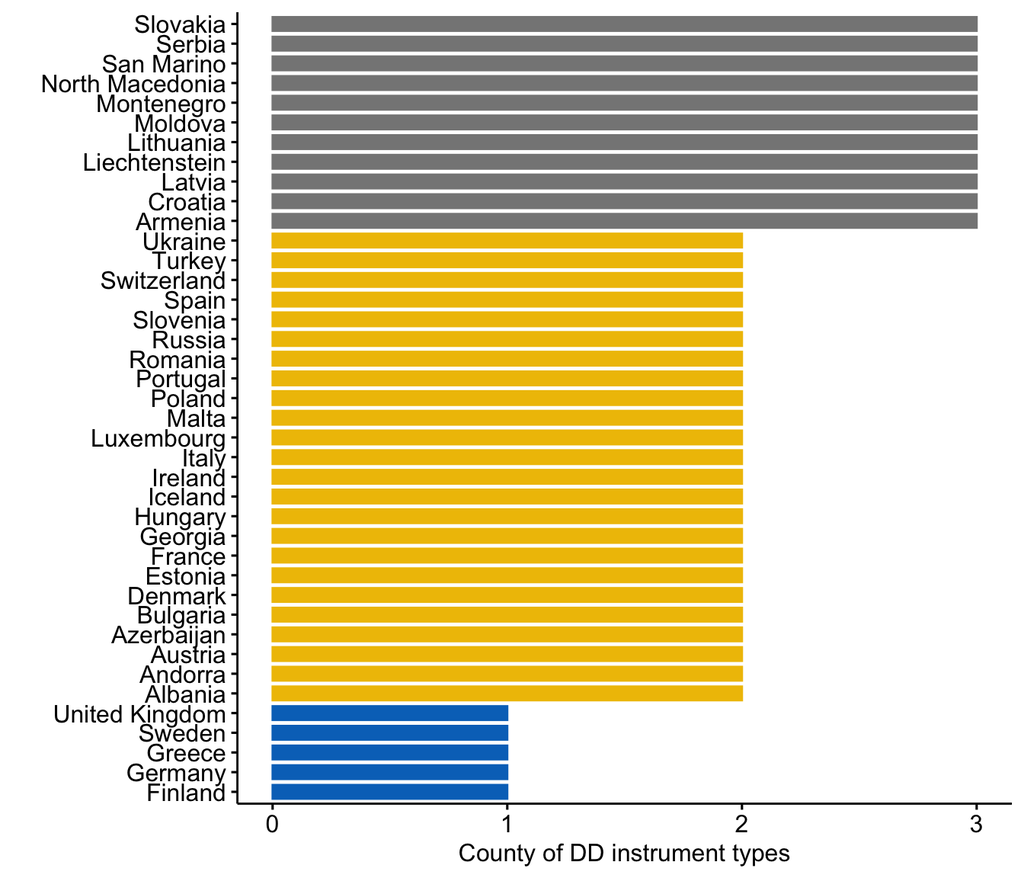

##### There are essentially 5 configurations + Germany on its own. See matrix below.

| Country | DD Config | N of countries |
| --- | --- | --- |
| Armenia | All 3 | 11 |
| Croatia | All 3 | 11 |
| Latvia | All 3 | 11 |
| Liechtenstein | All 3 | 11 |
| Lithuania | All 3 | 11 |
| Moldova | All 3 | 11 |
| Montenegro | All 3 | 11 |
| North Macedonia | All 3 | 11 |
| San Marino | All 3 | 11 |
| Serbia | All 3 | 11 |
| Slovakia | All 3 | 11 |
| Andorra | Law/Top | 10 |
| Austria | Law/Top | 10 |
| Denmark | Law/Top | 10 |
| Estonia | Law/Top | 10 |
| France | Law/Top | 10 |
| Iceland | Law/Top | 10 |
| Ireland | Law/Top | 10 |
| Romania | Law/Top | 10 |
| Spain | Law/Top | 10 |
| Turkey | Law/Top | 10 |
| Albania | Bottom/Top | 9 |
| Bulgaria | Bottom/Top | 9 |
| Georgia | Bottom/Top | 9 |
| Hungary | Bottom/Top | 9 |
| Italy | Bottom/Top | 9 |
| Luxembourg | Bottom/Top | 9 |
| Poland | Bottom/Top | 9 |
| Portugal | Bottom/Top | 9 |
| Slovenia | Bottom/Top | 9 |
| Azerbaijan | Bottom/Law | 5 |
| Malta | Bottom/Law | 5 |
| Russia | Bottom/Law | 5 |
| Switzerland | Bottom/Law | 5 |
| Ukraine | Bottom/Law | 5 |
| Finland | Top only | 4 |
| Greece | Top only | 4 |
| Sweden | Top only | 4 |
| United Kingdom | Top only | 4 |
| Germany | Law only | 1 |

# Conclusions

- Probably useful to look at the more basic 3 fold typology. In terms of CoE benchmarking, this reveals that most member states have different combinations of 2 types of referendum instruments. Nonetheless, somewhat surprisingly,the most common configuration is to have all 3 referendum instruments, 11 states share this configuration.
- Having *Country profiles* would be a very good idea (can be done by disaggregating the data at country level). Could take the form, Country X has Y instruments. Then we expand a little based on the Sources and Comments related to each instrument. This allows us to add important nuance to a Country profile.

The example of Spain is illustrative of the need for additional nuance, and where a Country Profile would help situate the DD context. It has 4 instruments: Agenda, Law, Executive and Legislature. However, Legislature-initiated can only be done under very specific conditions, a proposed constitutional amendment that has already achieved at least a two-thirds qualified majority in the parliament. Similarly, the Law-initiated referendum basically applies to a total revision of the Constitution (a bit like Germany). [these conditions are so rare that they never led to a national referendum since Spain’s 1970s transition to democracy]. On the other hand, the conditions for an Executive-initiated ref are more propitious. However, an Executive-initiated ref can only take place with Legislature approval. This latter element is no doubt typical of most Parliamentary systems … if Government wants a referendum it needs to get a referendum proposal through Parliament. This blurs the distinction between the two.

More generally, since Executive and Legislature are fused in parliamentary systems I would guess that, in practice, the distinction between Executive & Legislature initiated referendums is very blurred in such systems. Except for Cyprus/France, I think all EU countries are parliamentary systems (i.e., a parliamentary majority forms the govt); some other exceptions among the CoE states would include the Swiss system and true Presidential systems, where there is a clear separation of executive and parliament.